# Final version - HW3 - mw5599

```python
import pandas as pd
import numpy as np

s = '/Users/morganwaddington/Documents/Tandon/Classes/Machine-Learning/kddcup.data_10_percent_corrected'
df = pd.read_csv(s, header=None, encoding='utf-8')

#df = df.sample(frac=0.2, random_state=1)
```

```python
from sklearn.preprocessing import LabelEncoder

label_encoder = LabelEncoder()

for col in [1, 2, 3]:
    df.iloc[:, col] = label_encoder.fit_transform(df.iloc[:, col])
```

```python
y = df.iloc[:, 41].values

y = np.where(np.isin(y, ['back.', 'land.', 'neptune.', 'pod.', 'smurf.', 'teardrop.']), 0, 1)

X = df.iloc[:, 0:41].values #41 is correct
```

```python
from sklearn.model_selection import train_test_split
X_train, X_test, y_train, y_test = train_test_split(X, y, test_size=0.2, random_state=1, stratify=y)
```

```python
print('Labels counts in y:', np.bincount(y))
print('Labels counts in y_train:', np.bincount(y_train))
print('Labels counts in y_test:', np.bincount(y_test))
```

```
Labels counts in y: [391458 102563]
Labels counts in y_train: [313166  82050]
Labels counts in y_test: [78292 20513]
```

```python
from sklearn.preprocessing import StandardScaler
sc = StandardScaler()
sc.fit(X_train)
X_train_std = sc.transform(X_train)
X_test_std = sc.transform(X_test)

from imblearn.under_sampling import RandomUnderSampler
under = RandomUnderSampler(random_state=1)
X_train_std, y_train = under.fit_resample(X_train_std, y_train)

print('Labels counts in y_train after undersampling:', np.bincount(y_train))
```

```
Labels counts in y_train after undersampling: [82050 82050]
```

```python
from sklearn.metrics import accuracy_score, confusion_matrix, classification_report
from IPython.display import display, HTML

def print_results(y_train_pred, y_test_pred):
    cm = confusion_matrix(y_test, y_test_pred)
    print('Confusion Matrix:')
    print(cm,'\n')


    report = classification_report(y_test, y_test_pred)
    print('Classification Report:')
    print(report)

display(HTML(f"<h2>1. Using the Scikit-Learn Library train the SVM mode (using linear Kernel)</h2>"))

from sklearn.svm import SVC

svm_linear = SVC(kernel='linear', C=1.0, random_state=1)
svm_linear.fit(X_train_std, y_train)


y_train_pred = svm_linear.predict(X_train_std)
y_test_pred = svm_linear.predict(X_test_std)
display(HTML(f"<h2>Test result for LINEAR Kernel:</h2>"))
print_results(y_train_pred, y_test_pred)
```

1. Using the Scikit-Learn Library train the SVM mode (using linear Kernel)

Test result for LINEAR Kernel:

```
Confusion Matrix:
[[78261    31]
 [    9 20504]]

Classification Report:
              precision    recall  f1-score   support

           0       1.00      1.00      1.00     78292
           1       1.00      1.00      1.00     20513

    accuracy                           1.00     98805
   macro avg       1.00      1.00      1.00     98805
weighted avg       1.00      1.00      1.00     98805
```

The results demonstrate that the linear SVM model performs almost flawlessly. With a total of only 40 classification errors, the accuracy is essentially 100%. The perfect precision, recall, and f1-scores all show 1.00 which could not be better. This means that the linear SVM has successfully found a near-perfect decision boundary.

```python
from sklearn.svm import SVC

svm_linear = SVC(kernel='linear', C=1.0, random_state=1)
svm_linear.fit(X_train_std, y_train)

rbf = SVC(kernel='rbf', C=1.0, gamma=0.1, random_state=1)
rbf.fit(X_train_std, y_train)

sigmoid = SVC(kernel='sigmoid', C=1.0, gamma=0.001, random_state=1)
sigmoid.fit(X_train_std, y_train)

poly = SVC(kernel='poly', C=1.0, gamma=0.1, random_state=1)
poly.fit(X_train_std, y_train);
```

```python
display(HTML(f"<h2>PART 2. Running the SVM model four times using a different kernel each time using all the features.</h2>"))

y_train_pred = svm_linear.predict(X_train_std)
y_test_pred = svm_linear.predict(X_test_std)
display(HTML(f"<h2>Test result for LINEAR Kernel:</h2>"))
print_results(y_train_pred, y_test_pred)

y_train_pred = rbf.predict(X_train_std)
y_test_pred = rbf.predict(X_test_std)
display(HTML(f"<h2>Test result for RBF Kernel:</h2>"))
print_results(y_train_pred, y_test_pred)

y_train_pred = sigmoid.predict(X_train_std)
y_test_pred = sigmoid.predict(X_test_std)
display(HTML(f"<h2>Test result for SIGMOID Kernel:</h2>"))
print_results(y_train_pred, y_test_pred)

y_train_pred = poly.predict(X_train_std)
y_test_pred = poly.predict(X_test_std)
display(HTML(f"<h2>Test result for POLY Kernel:</h2>"))
print_results(y_train_pred, y_test_pred)
```

PART 2. Running the SVM model four times using a different kernel each time using all the features.

Test result for LINEAR Kernel:

```
Confusion Matrix:
[[78261    31]
 [    9 20504]]

Classification Report:
              precision    recall  f1-score   support

           0       1.00      1.00      1.00     78292
           1       1.00      1.00      1.00     20513

    accuracy                           1.00     98805
   macro avg       1.00      1.00      1.00     98805
weighted avg       1.00      1.00      1.00     98805
```

Test result for RBF Kernel:

```
Confusion Matrix:
[[78264    28]
 [    0 20513]]

Classification Report:
              precision    recall  f1-score   support

           0       1.00      1.00      1.00     78292
           1       1.00      1.00      1.00     20513

    accuracy                           1.00     98805
   macro avg       1.00      1.00      1.00     98805
weighted avg       1.00      1.00      1.00     98805
```

Test result for SIGMOID Kernel:

```
Confusion Matrix:
[[77813   479]
 [   32 20481]]

Classification Report:
              precision    recall  f1-score   support

           0       1.00      0.99      1.00     78292
           1       0.98      1.00      0.99     20513

    accuracy                           0.99     98805
   macro avg       0.99      1.00      0.99     98805
weighted avg       0.99      0.99      0.99     98805
```

Test result for POLY Kernel:

```
Confusion Matrix:
[[78269    23]
 [    2 20511]]

Classification Report:
              precision    recall  f1-score   support

           0       1.00      1.00      1.00     78292
           1       1.00      1.00      1.00     20513

    accuracy                           1.00     98805
   macro avg       1.00      1.00      1.00     98805
weighted avg       1.00      1.00      1.00     98805
```

You can see the results are largely similar to what was discussed above, with overall near perfect results. The results show that the linear, polynomial and RBF kernels perform almost perfectly with only a handfull of errors each. This indicates that the data is likely well-separable. The sigmoid kernel performs the worst, with many false positives, suggesting it struggles to capture the data patterns effectively. It is also important to note that for sigmoid I had to reduce the gamma to 0.001 to attain the smaller amount of errors you see above (the standard 0.1 led to hundreds of additional errors). My understanding is that the KDD99 dataset has a lot of complex patterns, and the sigmoid kernel (which is akin to a simple neural network) can't capture those patterns very well. That being said -- with the correct gamma it is still acheiving a 99% accuracy. Poly and RBF are designed in a way to handle more complex relationships so I guess it makes sense we are seeing 100% accuracy.

```python
display(HTML(f"<h2>PART 3. Pick two features / Train SVM model using only those two features / Visualize the decision boundary.</h2>"))
```

PART 3. Pick two features / Train SVM model using only those two features / Visualize the decision boundary.

```python
feature_names = [
    'duration', 'protocol_type', 'service', 'flag', 'src_bytes', 'dst_bytes',
    'land', 'wrong_fragment', 'urgent', 'hot', 'num_failed_logins',
    'logged_in', 'num_compromised', 'root_shell', 'su_attempted', 'num_root',
    'num_file_creations', 'num_shells', 'num_access_files', 'num_outbound_cmds',
    'is_host_login', 'is_guest_login', 'count', 'srv_count', 'serror_rate',
    'srv_serror_rate', 'rerror_rate', 'srv_rerror_rate', 'same_srv_rate',
    'diff_srv_rate', 'srv_diff_host_rate', 'dst_host_count', 'dst_host_srv_count',
    'dst_host_same_srv_rate', 'dst_host_diff_srv_rate', 'dst_host_same_src_port_rate',
    'dst_host_srv_diff_host_rate', 'dst_host_serror_rate', 'dst_host_srv_serror_rate',
    'dst_host_rerror_rate', 'dst_host_srv_rerror_rate'
]


idx_dst_host_srv_diff_host_rate = feature_names.index('dst_host_srv_diff_host_rate')
idx_dst_bytes = feature_names.index('dst_bytes')

X = df.iloc[:, [idx_dst_host_srv_diff_host_rate, idx_dst_bytes]].values

X_train, X_test, y_train, y_test = train_test_split(X, y, test_size=0.2, random_state=1, stratify=y)

sc.fit(X_train)
X_train_std = sc.transform(X_train)
X_test_std = sc.transform(X_test)

X_train_std, y_train = under.fit_resample(X_train_std, y_train)

print('\nLabels counts in y_train after undersampling:', np.bincount(y_train))
```

```
Labels counts in y_train after undersampling: [82050 82050]
```

```python
svm_linear = SVC(kernel='linear', C=1.0, random_state=1)
svm_linear.fit(X_train_std, y_train)

rbf = SVC(kernel='rbf', C=1.0, gamma=0.1, random_state=1)
rbf.fit(X_train_std, y_train)


y_train_pred = svm_linear.predict(X_train_std)
y_test_pred = svm_linear.predict(X_test_std)
display(HTML(f"<h2>Test result for LINEAR Kernel:</h2>"))
print_results(y_train_pred, y_test_pred)

y_train_pred = rbf.predict(X_train_std)
y_test_pred = rbf.predict(X_test_std)
display(HTML(f"<h2>Test result for RBF Kernel:</h2>"))
print_results(y_train_pred, y_test_pred)
```

Test result for LINEAR Kernel:

```
Confusion Matrix:
[[77833   459]
 [ 6568 13945]]

Classification Report:
              precision    recall  f1-score   support

           0       0.92      0.99      0.96     78292
           1       0.97      0.68      0.80     20513

    accuracy                           0.93     98805
   macro avg       0.95      0.84      0.88     98805
weighted avg       0.93      0.93      0.92     98805
```

Test result for RBF Kernel:

```
Confusion Matrix:
[[77833   459]
 [ 7136 13377]]

Classification Report:
              precision    recall  f1-score   support

           0       0.92      0.99      0.95     78292
           1       0.97      0.65      0.78     20513

    accuracy                           0.92     98805
   macro avg       0.94      0.82      0.87     98805
weighted avg       0.93      0.92      0.92     98805
```

I chose dst_host_srv_diff_host_rate and dst_bytes as my two features because they offer good variability, allowing the data points to spread out across a wider range on the plot, unlike features that are mostly binary and cluster in a small area. During DoS attacks, the services used may vary, leading to higher values for dst_host_srv_diff_host_rate compared to normal traffic. More importantly, since servers are overwhelmed during these attacks, they can't respond with much data, resulting in dst_bytes values being close to 0. This makes these two features effective for identifying patterns related to DoS attacks.

As you can see the models are a lot worse with only two features than it is with all 41 features (which I guess makes sense, more info leads to better guesses). Of course the results are not terrible, with both kernels reaching 92/93% accuracy. Both Linear and RBF perform well in detecting DoS attacks, with high precision 92% and recall 99%. However, both struggle with non-DoS traffic, especially in terms of recall, where the Linear kernel achieves 0.68 and the RBF kernel only 0.65. This indicates that the models miss a significant portion of non-DoS instances. In conclusion the Linear kernel might be a bit better as it slightly outperforms the RBF kernel on non-DoS traffic.

```python
from matplotlib.colors import ListedColormap
import matplotlib.pyplot as plt

def plot_decision_regions(X, y, classifier):
    markers = ('s', 'o')
    colors = ('red', 'blue')
    cmap = ListedColormap(colors[:len(np.unique(y))])

    resolution = 0.01
    x1_min, x1_max = X[:, 0].min() - 1, 2.1
    x2_min, x2_max = X[:, 1].min() - 1, 4
    xx1, xx2 = np.meshgrid(
        np.arange(x1_min, x1_max, resolution),
        np.arange(x2_min, x2_max, resolution))

    Z = classifier.predict(np.array([xx1.ravel(), xx2.ravel()]).T)
    Z = Z.reshape(xx1.shape)

    plt.figure(figsize=(10, 6))
    plt.contourf(xx1, xx2, Z, alpha=0.3, cmap=cmap)
    plt.xlim(xx1.min(), xx1.max())
    plt.ylim(xx2.min(), xx2.max())

    for idx, cl in enumerate(np.unique(y)):
        plt.scatter(
            x=X[y == cl, 0], y=X[y == cl, 1],
            alpha=0.8,
            edgecolor=colors[idx]if cl ==1 else 'black',
            facecolors='none' if cl == 1 else colors[idx],
            marker=markers[idx], label=f'Class {cl}',
            linewidth=1.5,
            s=100 if cl == 0 else 200,
            zorder=2 if cl == 0 else 1)

    plt.xlabel('idx_dst_host_srv_diff_host_rate [standardized]')
    plt.ylabel('idx_dst_bytes [standardized]')
    plt.legend(loc='upper left')
    plt.tight_layout()
```

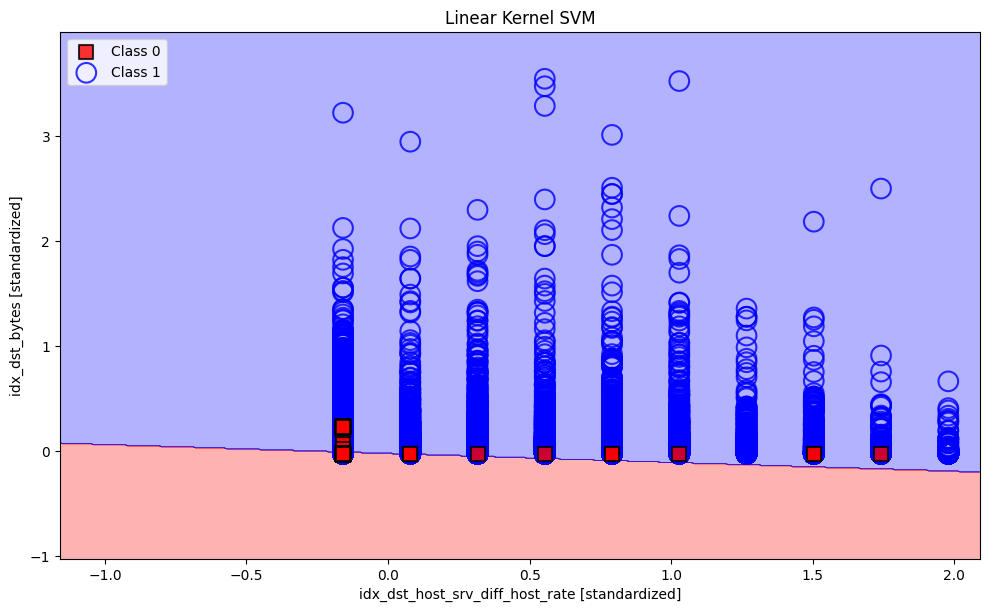

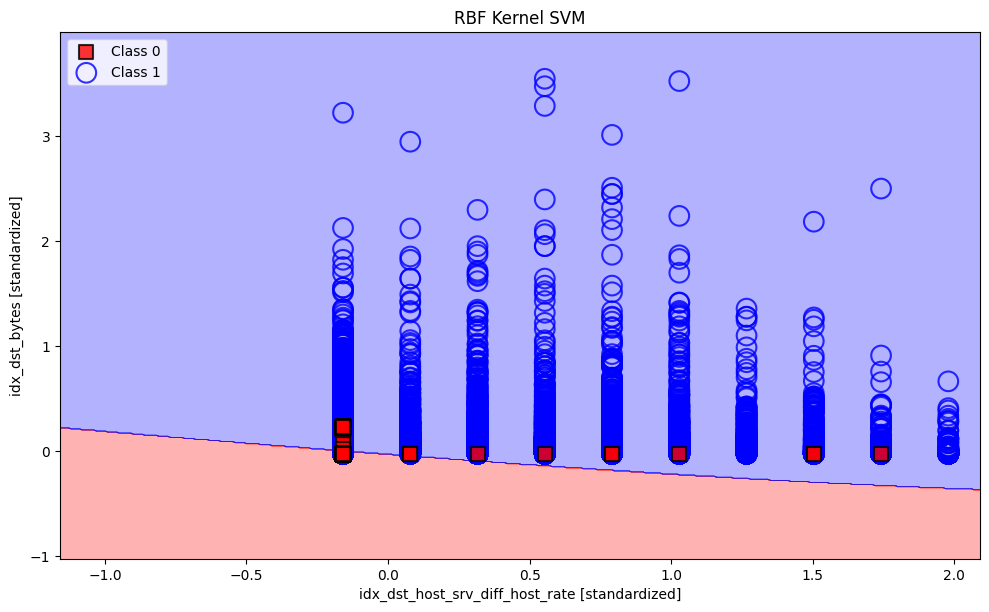

```python
plot_decision_regions(X_test_std,
                      y_test,
                      classifier=svm_linear)
plt.title('Linear Kernel SVM')
plt.show()

plot_decision_regions(X_test_std,
                      y_test,
                      classifier=rbf)
plt.title('RBF Kernel SVM')
plt.show()
```

Seeing this graph we understand better why the models performed a lot words with two features: While DoS attacks generally have lower dst_bytes values, leading to some separation, there's significant massive overlapp with Class 1, especially at lower dst_bytes values. Because of the overlap it is impossible for the model to distinguishing Dos and non-DoS attacks as we saw with the lower recall value. Finally we see that The RBF kernel has a steeper slope which I take is due to model attempt to addapt to complex patterns (with data largely overlapping along the 0 axis).On the other hand, the linear kernel's flatter boundary shows a simpler approach towards separating between classes.